# Risk Factor Analysis

## Outcome Variable

**Outcome Variable:** ever_co

## Predictor Variables

**Intervention Variable:** predfeed36

**Adjustment Set:**

- arm
- sex
- month
- brthmon
- W_mage
- meducyrs
- feducyrs
- hhwealth_quart
- hfoodsec
- W_mhtcm
- vagbrth
- W_gagebrth
- W_birthwt
- W_birthlen
- W_nrooms
- W_nchldlt5
- W_parity
- impfloor
- impsan
- safeh20
- delta_W_mage
- delta_meducyrs
- delta_feducyrs
- delta_hhwealth_quart
- delta_hfoodsec
- delta_W_mhtcm
- delta_vagbrth
- delta_W_gagebrth
- delta_W_birthwt
- delta_W_birthlen
- delta_W_nrooms
- delta_W_nchldlt5
- delta_W_parity
- delta_impfloor
- delta_impsan
- delta_safeh20

## Stratifying Variables

The analysis was stratified on these variable(s):

- agecat
- studyid
- country

## Data Summary

| agecat | studyid | country | predfeed36 | ever_co | n_cell | n |
| --- | --- | --- | --- | --- | --- | --- |
| 0-24 months | ki0047075b-MAL-ED | BANGLADESH | 1 | 0 | 108 | 251 |
| 0-24 months | ki0047075b-MAL-ED | BANGLADESH | 1 | 1 | 23 | 251 |
| 0-24 months | ki0047075b-MAL-ED | BANGLADESH | 0 | 0 | 104 | 251 |
| 0-24 months | ki0047075b-MAL-ED | BANGLADESH | 0 | 1 | 16 | 251 |
| 0-24 months | ki0047075b-MAL-ED | BRAZIL | 1 | 0 | 38 | 225 |
| 0-24 months | ki0047075b-MAL-ED | BRAZIL | 1 | 1 | 0 | 225 |
| 0-24 months | ki0047075b-MAL-ED | BRAZIL | 0 | 0 | 185 | 225 |
| 0-24 months | ki0047075b-MAL-ED | BRAZIL | 0 | 1 | 2 | 225 |
| 0-24 months | ki0047075b-MAL-ED | INDIA | 1 | 0 | 17 | 243 |
| 0-24 months | ki0047075b-MAL-ED | INDIA | 1 | 1 | 3 | 243 |
| 0-24 months | ki0047075b-MAL-ED | INDIA | 0 | 0 | 172 | 243 |
| 0-24 months | ki0047075b-MAL-ED | INDIA | 0 | 1 | 51 | 243 |
| 0-24 months | ki0047075b-MAL-ED | NEPAL | 1 | 0 | 28 | 238 |
| 0-24 months | ki0047075b-MAL-ED | NEPAL | 1 | 1 | 4 | 238 |
| 0-24 months | ki0047075b-MAL-ED | NEPAL | 0 | 0 | 189 | 238 |
| 0-24 months | ki0047075b-MAL-ED | NEPAL | 0 | 1 | 17 | 238 |
| 0-24 months | ki0047075b-MAL-ED | PERU | 1 | 0 | 126 | 287 |
| 0-24 months | ki0047075b-MAL-ED | PERU | 1 | 1 | 1 | 287 |
| 0-24 months | ki0047075b-MAL-ED | PERU | 0 | 0 | 150 | 287 |
| 0-24 months | ki0047075b-MAL-ED | PERU | 0 | 1 | 10 | 287 |
| 0-24 months | ki0047075b-MAL-ED | SOUTH AFRICA | 1 | 0 | 3 | 281 |
| 0-24 months | ki0047075b-MAL-ED | SOUTH AFRICA | 1 | 1 | 0 | 281 |
| 0-24 months | ki0047075b-MAL-ED | SOUTH AFRICA | 0 | 0 | 257 | 281 |
| 0-24 months | ki0047075b-MAL-ED | SOUTH AFRICA | 0 | 1 | 21 | 281 |
| 0-24 months | ki0047075b-MAL-ED | TANZANIA, UNITED REPUBLIC OF | 1 | 0 | 2 | 256 |
| 0-24 months | ki0047075b-MAL-ED | TANZANIA, UNITED REPUBLIC OF | 1 | 1 | 0 | 256 |
| 0-24 months | ki0047075b-MAL-ED | TANZANIA, UNITED REPUBLIC OF | 0 | 0 | 231 | 256 |
| 0-24 months | ki0047075b-MAL-ED | TANZANIA, UNITED REPUBLIC OF | 0 | 1 | 23 | 256 |
| 0-24 months | ki1000109-EE | PAKISTAN | 1 | 0 | 140 | 373 |
| 0-24 months | ki1000109-EE | PAKISTAN | 1 | 1 | 86 | 373 |

[output cut: 126 more lines]

The following strata were considered:

- agecat: 0-24 months, studyid: ki0047075b-MAL-ED, country: BANGLADESH
- agecat: 0-24 months, studyid: ki0047075b-MAL-ED, country: BRAZIL
- agecat: 0-24 months, studyid: ki0047075b-MAL-ED, country: INDIA
- agecat: 0-24 months, studyid: ki0047075b-MAL-ED, country: NEPAL
- agecat: 0-24 months, studyid: ki0047075b-MAL-ED, country: PERU
- agecat: 0-24 months, studyid: ki0047075b-MAL-ED, country: SOUTH AFRICA
- agecat: 0-24 months, studyid: ki0047075b-MAL-ED, country: TANZANIA, UNITED REPUBLIC OF
- agecat: 0-24 months, studyid: ki1000109-EE, country: PAKISTAN
- agecat: 0-24 months, studyid: ki1000304b-SAS-FoodSuppl, country: INDIA
- agecat: 0-24 months, studyid: ki1113344-GMS-Nepal, country: NEPAL
- agecat: 0-24 months, studyid: ki1148112-LCNI-5, country: MALAWI
- agecat: 0-24 months, studyid: kiGH5241-JiVitA-3, country: BANGLADESH
- agecat: 0-24 months, studyid: kiGH5241-JiVitA-4, country: BANGLADESH
- agecat: 0-6 months, studyid: ki0047075b-MAL-ED, country: BANGLADESH
- agecat: 0-6 months, studyid: ki0047075b-MAL-ED, country: BRAZIL
- agecat: 0-6 months, studyid: ki0047075b-MAL-ED, country: INDIA
- agecat: 0-6 months, studyid: ki0047075b-MAL-ED, country: NEPAL
- agecat: 0-6 months, studyid: ki0047075b-MAL-ED, country: PERU
- agecat: 0-6 months, studyid: ki0047075b-MAL-ED, country: SOUTH AFRICA
- agecat: 0-6 months, studyid: ki0047075b-MAL-ED, country: TANZANIA, UNITED REPUBLIC OF
- agecat: 0-6 months, studyid: ki1000109-EE, country: PAKISTAN
- agecat: 0-6 months, studyid: ki1000304b-SAS-FoodSuppl, country: INDIA
- agecat: 0-6 months, studyid: ki1113344-GMS-Nepal, country: NEPAL
- agecat: 0-6 months, studyid: ki1148112-LCNI-5, country: MALAWI
- agecat: 0-6 months, studyid: kiGH5241-JiVitA-3, country: BANGLADESH
- agecat: 0-6 months, studyid: kiGH5241-JiVitA-4, country: BANGLADESH
- agecat: 6-24 months, studyid: ki0047075b-MAL-ED, country: BANGLADESH
- agecat: 6-24 months, studyid: ki0047075b-MAL-ED, country: BRAZIL
- agecat: 6-24 months, studyid: ki0047075b-MAL-ED, country: INDIA
- agecat: 6-24 months, studyid: ki0047075b-MAL-ED, country: NEPAL
- agecat: 6-24 months, studyid: ki0047075b-MAL-ED, country: PERU
- agecat: 6-24 months, studyid: ki0047075b-MAL-ED, country: SOUTH AFRICA
- agecat: 6-24 months, studyid: ki0047075b-MAL-ED, country: TANZANIA, UNITED REPUBLIC OF
- agecat: 6-24 months, studyid: ki1000109-EE, country: PAKISTAN
- agecat: 6-24 months, studyid: ki1000304b-SAS-FoodSuppl, country: INDIA
- agecat: 6-24 months, studyid: ki1113344-GMS-Nepal, country: NEPAL
- agecat: 6-24 months, studyid: ki1148112-LCNI-5, country: MALAWI
- agecat: 6-24 months, studyid: kiGH5241-JiVitA-3, country: BANGLADESH
- agecat: 6-24 months, studyid: kiGH5241-JiVitA-4, country: BANGLADESH

### Dropped Strata

Some strata were dropped due to rare outcomes:

- agecat: 0-24 months, studyid: ki0047075b-MAL-ED, country: BRAZIL
- agecat: 0-24 months, studyid: ki0047075b-MAL-ED, country: INDIA
- agecat: 0-24 months, studyid: ki0047075b-MAL-ED, country: NEPAL
- agecat: 0-24 months, studyid: ki0047075b-MAL-ED, country: PERU
- agecat: 0-24 months, studyid: ki0047075b-MAL-ED, country: SOUTH AFRICA
- agecat: 0-24 months, studyid: ki0047075b-MAL-ED, country: TANZANIA, UNITED REPUBLIC OF
- agecat: 0-24 months, studyid: ki1000304b-SAS-FoodSuppl, country: INDIA
- agecat: 0-24 months, studyid: ki1148112-LCNI-5, country: MALAWI
- agecat: 0-6 months, studyid: ki0047075b-MAL-ED, country: BANGLADESH
- agecat: 0-6 months, studyid: ki0047075b-MAL-ED, country: BRAZIL
- agecat: 0-6 months, studyid: ki0047075b-MAL-ED, country: INDIA
- agecat: 0-6 months, studyid: ki0047075b-MAL-ED, country: NEPAL
- agecat: 0-6 months, studyid: ki0047075b-MAL-ED, country: PERU
- agecat: 0-6 months, studyid: ki0047075b-MAL-ED, country: SOUTH AFRICA
- agecat: 0-6 months, studyid: ki0047075b-MAL-ED, country: TANZANIA, UNITED REPUBLIC OF
- agecat: 0-6 months, studyid: ki1000304b-SAS-FoodSuppl, country: INDIA
- agecat: 0-6 months, studyid: ki1148112-LCNI-5, country: MALAWI
- agecat: 6-24 months, studyid: ki0047075b-MAL-ED, country: BRAZIL
- agecat: 6-24 months, studyid: ki0047075b-MAL-ED, country: INDIA
- agecat: 6-24 months, studyid: ki0047075b-MAL-ED, country: NEPAL
- agecat: 6-24 months, studyid: ki0047075b-MAL-ED, country: PERU
- agecat: 6-24 months, studyid: ki0047075b-MAL-ED, country: SOUTH AFRICA
- agecat: 6-24 months, studyid: ki0047075b-MAL-ED, country: TANZANIA, UNITED REPUBLIC OF
- agecat: 6-24 months, studyid: ki1000304b-SAS-FoodSuppl, country: INDIA
- agecat: 6-24 months, studyid: ki1148112-LCNI-5, country: MALAWI

## Methods Detail

We’re interested in the causal parameters $E[Y_a]$ for all values of $a \in \mathcal{A}$. These parameters represent the mean outcome if, possibly contrary to fact, we intervened to set all units to have $A=a$. Under the randomization and positivity assumptions, these are identified by the statistical parameters $\psi_a=E_W[E_{Y|A,W}(Y|A=a,W)]$. In addition, we’re interested in the mean of $Y$, $E[Y]$ under no intervention (the observed mean). We will estimate these parameters by using SuperLearner to fit the relevant likelihood factors – $E_{Y|A,W}(Y|A=a,W)$ and $p(A=a|W)$, and then updating our likelihood fit using a joint TMLE.

For unadjusted analyses ($W=\{\}$), initial likelihoods were estimated using Lrnr_glm to estimate the simple $E(Y|A)$ and Lrnr_mean to estimate $p(A)$. For adjusted analyses, a small library containing Lrnr_glmnet, Lrnr_xgboost, and Lrnr_mean was used.

Having estimated these parameters, we will then use the delta method to estimate relative risks and attributable risks relative to a prespecified baseline level of $A$.

# Results Detail

## Results Plots

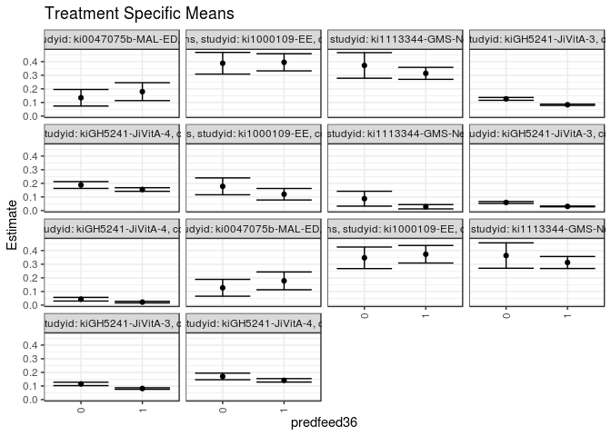

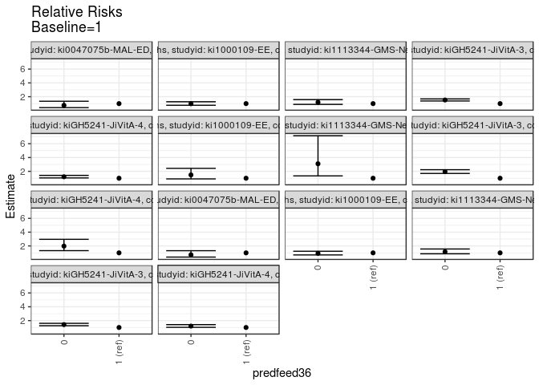

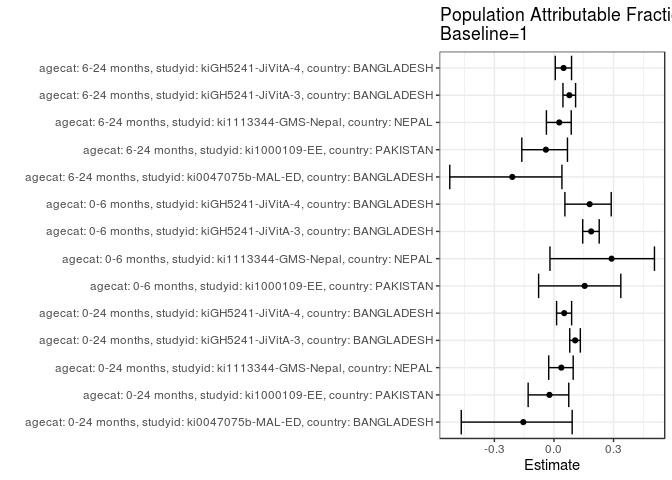

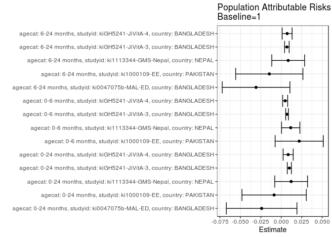

## Results Table

### Parameter: TSM

| agecat | studyid | country | intervention_level | baseline_level | estimate | ci_lower | ci_upper |
| --- | --- | --- | --- | --- | --- | --- | --- |
| 0-24 months | ki0047075b-MAL-ED | BANGLADESH | 1 | NA | 0.1793557 | 0.1136014 | 0.2451101 |
| 0-24 months | ki0047075b-MAL-ED | BANGLADESH | 0 | NA | 0.1346021 | 0.0737892 | 0.1954150 |
| 0-24 months | ki1000109-EE | PAKISTAN | 1 | NA | 0.3948152 | 0.3317245 | 0.4579059 |
| 0-24 months | ki1000109-EE | PAKISTAN | 0 | NA | 0.3878247 | 0.3082818 | 0.4673676 |
| 0-24 months | ki1113344-GMS-Nepal | NEPAL | 1 | NA | 0.3136803 | 0.2697024 | 0.3576582 |
| 0-24 months | ki1113344-GMS-Nepal | NEPAL | 0 | NA | 0.3716953 | 0.2778252 | 0.4655654 |
| 0-24 months | kiGH5241-JiVitA-3 | BANGLADESH | 1 | NA | 0.0829205 | 0.0781855 | 0.0876554 |
| 0-24 months | kiGH5241-JiVitA-3 | BANGLADESH | 0 | NA | 0.1263221 | 0.1159033 | 0.1367409 |
| 0-24 months | kiGH5241-JiVitA-4 | BANGLADESH | 1 | NA | 0.1545703 | 0.1412982 | 0.1678423 |
| 0-24 months | kiGH5241-JiVitA-4 | BANGLADESH | 0 | NA | 0.1877576 | 0.1627760 | 0.2127392 |
| 0-6 months | ki1000109-EE | PAKISTAN | 1 | NA | 0.1201269 | 0.0778101 | 0.1624438 |
| 0-6 months | ki1000109-EE | PAKISTAN | 0 | NA | 0.1779421 | 0.1160311 | 0.2398530 |
| 0-6 months | ki1113344-GMS-Nepal | NEPAL | 1 | NA | 0.0282353 | 0.0124722 | 0.0439984 |
| 0-6 months | ki1113344-GMS-Nepal | NEPAL | 0 | NA | 0.0873786 | 0.0327917 | 0.1419656 |
| 0-6 months | kiGH5241-JiVitA-3 | BANGLADESH | 1 | NA | 0.0306705 | 0.0279043 | 0.0334367 |
| 0-6 months | kiGH5241-JiVitA-3 | BANGLADESH | 0 | NA | 0.0597103 | 0.0526382 | 0.0667823 |
| 0-6 months | kiGH5241-JiVitA-4 | BANGLADESH | 1 | NA | 0.0218353 | 0.0159263 | 0.0277442 |
| 0-6 months | kiGH5241-JiVitA-4 | BANGLADESH | 0 | NA | 0.0431816 | 0.0297587 | 0.0566045 |
| 6-24 months | ki0047075b-MAL-ED | BANGLADESH | 1 | NA | 0.1779093 | 0.1126028 | 0.2432158 |
| 6-24 months | ki0047075b-MAL-ED | BANGLADESH | 0 | NA | 0.1270605 | 0.0651536 | 0.1889674 |
| 6-24 months | ki1000109-EE | PAKISTAN | 1 | NA | 0.3732949 | 0.3087295 | 0.4378603 |
| 6-24 months | ki1000109-EE | PAKISTAN | 0 | NA | 0.3471354 | 0.2680519 | 0.4262189 |
| 6-24 months | ki1113344-GMS-Nepal | NEPAL | 1 | NA | 0.3128080 | 0.2686623 | 0.3569538 |
| 6-24 months | ki1113344-GMS-Nepal | NEPAL | 0 | NA | 0.3636936 | 0.2703937 | 0.4569935 |
| 6-24 months | kiGH5241-JiVitA-3 | BANGLADESH | 1 | NA | 0.0813055 | 0.0758229 | 0.0867880 |
| 6-24 months | kiGH5241-JiVitA-3 | BANGLADESH | 0 | NA | 0.1151687 | 0.1025975 | 0.1277398 |
| 6-24 months | kiGH5241-JiVitA-4 | BANGLADESH | 1 | NA | 0.1414684 | 0.1288645 | 0.1540723 |
| 6-24 months | kiGH5241-JiVitA-4 | BANGLADESH | 0 | NA | 0.1699851 | 0.1460298 | 0.1939403 |

### Parameter: E(Y)

| agecat | studyid | country | intervention_level | baseline_level | estimate | ci_lower | ci_upper |
| --- | --- | --- | --- | --- | --- | --- | --- |
| 0-24 months | ki0047075b-MAL-ED | BANGLADESH | NA | NA | 0.1553785 | 0.1104725 | 0.2002845 |
| 0-24 months | ki1000109-EE | PAKISTAN | NA | NA | 0.3860590 | 0.3365861 | 0.4355318 |
| 0-24 months | ki1113344-GMS-Nepal | NEPAL | NA | NA | 0.3257576 | 0.2857449 | 0.3657703 |
| 0-24 months | kiGH5241-JiVitA-3 | BANGLADESH | NA | NA | 0.0928037 | 0.0883057 | 0.0973017 |
| 0-24 months | kiGH5241-JiVitA-4 | BANGLADESH | NA | NA | 0.1630101 | 0.1508647 | 0.1751555 |
| 0-6 months | ki1000109-EE | PAKISTAN | NA | NA | 0.1420912 | 0.1066114 | 0.1775709 |
| 0-6 months | ki1113344-GMS-Nepal | NEPAL | NA | NA | 0.0397727 | 0.0230879 | 0.0564576 |
| 0-6 months | kiGH5241-JiVitA-3 | BANGLADESH | NA | NA | 0.0377388 | 0.0349183 | 0.0405593 |
| 0-6 months | kiGH5241-JiVitA-4 | BANGLADESH | NA | NA | 0.0266227 | 0.0211044 | 0.0321409 |
| 6-24 months | ki0047075b-MAL-ED | BANGLADESH | NA | NA | 0.1470588 | 0.1019690 | 0.1921487 |
| 6-24 months | ki1000109-EE | PAKISTAN | NA | NA | 0.3586957 | 0.3096263 | 0.4077650 |
| 6-24 months | ki1113344-GMS-Nepal | NEPAL | NA | NA | 0.3212928 | 0.2813480 | 0.3612376 |
| 6-24 months | kiGH5241-JiVitA-3 | BANGLADESH | NA | NA | 0.0881474 | 0.0829797 | 0.0933152 |
| 6-24 months | kiGH5241-JiVitA-4 | BANGLADESH | NA | NA | 0.1486695 | 0.1373410 | 0.1599979 |

### Parameter: RR

| agecat | studyid | country | intervention_level | baseline_level | estimate | ci_lower | ci_upper |
| --- | --- | --- | --- | --- | --- | --- | --- |
| 0-24 months | ki0047075b-MAL-ED | BANGLADESH | 1 | 1 | 1.0000000 | 1.0000000 | 1.000000 |
| 0-24 months | ki0047075b-MAL-ED | BANGLADESH | 0 | 1 | 0.7504755 | 0.4199265 | 1.341219 |
| 0-24 months | ki1000109-EE | PAKISTAN | 1 | 1 | 1.0000000 | 1.0000000 | 1.000000 |
| 0-24 months | ki1000109-EE | PAKISTAN | 0 | 1 | 0.9822943 | 0.7604524 | 1.268853 |
| 0-24 months | ki1113344-GMS-Nepal | NEPAL | 1 | 1 | 1.0000000 | 1.0000000 | 1.000000 |
| 0-24 months | ki1113344-GMS-Nepal | NEPAL | 0 | 1 | 1.1849496 | 0.8890647 | 1.579306 |
| 0-24 months | kiGH5241-JiVitA-3 | BANGLADESH | 1 | 1 | 1.0000000 | 1.0000000 | 1.000000 |
| 0-24 months | kiGH5241-JiVitA-3 | BANGLADESH | 0 | 1 | 1.5234129 | 1.3829370 | 1.678158 |
| 0-24 months | kiGH5241-JiVitA-4 | BANGLADESH | 1 | 1 | 1.0000000 | 1.0000000 | 1.000000 |
| 0-24 months | kiGH5241-JiVitA-4 | BANGLADESH | 0 | 1 | 1.2147074 | 1.0441781 | 1.413086 |
| 0-6 months | ki1000109-EE | PAKISTAN | 1 | 1 | 1.0000000 | 1.0000000 | 1.000000 |
| 0-6 months | ki1000109-EE | PAKISTAN | 0 | 1 | 1.4812836 | 0.9036793 | 2.428075 |
| 0-6 months | ki1113344-GMS-Nepal | NEPAL | 1 | 1 | 1.0000000 | 1.0000000 | 1.000000 |
| 0-6 months | ki1113344-GMS-Nepal | NEPAL | 0 | 1 | 3.0946602 | 1.3389106 | 7.152771 |
| 0-6 months | kiGH5241-JiVitA-3 | BANGLADESH | 1 | 1 | 1.0000000 | 1.0000000 | 1.000000 |
| 0-6 months | kiGH5241-JiVitA-3 | BANGLADESH | 0 | 1 | 1.9468299 | 1.6939747 | 2.237428 |
| 0-6 months | kiGH5241-JiVitA-4 | BANGLADESH | 1 | 1 | 1.0000000 | 1.0000000 | 1.000000 |
| 0-6 months | kiGH5241-JiVitA-4 | BANGLADESH | 0 | 1 | 1.9776078 | 1.3202446 | 2.962279 |
| 6-24 months | ki0047075b-MAL-ED | BANGLADESH | 1 | 1 | 1.0000000 | 1.0000000 | 1.000000 |
| 6-24 months | ki0047075b-MAL-ED | BANGLADESH | 0 | 1 | 0.7141868 | 0.3882339 | 1.313803 |
| 6-24 months | ki1000109-EE | PAKISTAN | 1 | 1 | 1.0000000 | 1.0000000 | 1.000000 |
| 6-24 months | ki1000109-EE | PAKISTAN | 0 | 1 | 0.9299228 | 0.6994184 | 1.236394 |
| 6-24 months | ki1113344-GMS-Nepal | NEPAL | 1 | 1 | 1.0000000 | 1.0000000 | 1.000000 |
| 6-24 months | ki1113344-GMS-Nepal | NEPAL | 0 | 1 | 1.1626735 | 0.8678664 | 1.557624 |
| 6-24 months | kiGH5241-JiVitA-3 | BANGLADESH | 1 | 1 | 1.0000000 | 1.0000000 | 1.000000 |
| 6-24 months | kiGH5241-JiVitA-3 | BANGLADESH | 0 | 1 | 1.4164937 | 1.2498731 | 1.605327 |
| 6-24 months | kiGH5241-JiVitA-4 | BANGLADESH | 1 | 1 | 1.0000000 | 1.0000000 | 1.000000 |
| 6-24 months | kiGH5241-JiVitA-4 | BANGLADESH | 0 | 1 | 1.2015763 | 1.0206726 | 1.414543 |

### Parameter: PAR

| agecat | studyid | country | intervention_level | baseline_level | estimate | ci_lower | ci_upper |
| --- | --- | --- | --- | --- | --- | --- | --- |
| 0-24 months | ki0047075b-MAL-ED | BANGLADESH | 1 | NA | -0.0239772 | -0.0671809 | 0.0192265 |
| 0-24 months | ki1000109-EE | PAKISTAN | 1 | NA | -0.0087562 | -0.0481354 | 0.0306230 |
| 0-24 months | ki1113344-GMS-Nepal | NEPAL | 1 | NA | 0.0120773 | -0.0079867 | 0.0321412 |
| 0-24 months | kiGH5241-JiVitA-3 | BANGLADESH | 1 | NA | 0.0098833 | 0.0073686 | 0.0123979 |
| 0-24 months | kiGH5241-JiVitA-4 | BANGLADESH | 1 | NA | 0.0084398 | 0.0022620 | 0.0146177 |
| 0-6 months | ki1000109-EE | PAKISTAN | 1 | NA | 0.0219642 | -0.0075283 | 0.0514567 |
| 0-6 months | ki1113344-GMS-Nepal | NEPAL | 1 | NA | 0.0115374 | 0.0002746 | 0.0228003 |
| 0-6 months | kiGH5241-JiVitA-3 | BANGLADESH | 1 | NA | 0.0070683 | 0.0054094 | 0.0087272 |
| 0-6 months | kiGH5241-JiVitA-4 | BANGLADESH | 1 | NA | 0.0047874 | 0.0017075 | 0.0078673 |
| 6-24 months | ki0047075b-MAL-ED | BANGLADESH | 1 | NA | -0.0308505 | -0.0722397 | 0.0105388 |
| 6-24 months | ki1000109-EE | PAKISTAN | 1 | NA | -0.0145992 | -0.0557362 | 0.0265378 |
| 6-24 months | ki1113344-GMS-Nepal | NEPAL | 1 | NA | 0.0084847 | -0.0115886 | 0.0285581 |
| 6-24 months | kiGH5241-JiVitA-3 | BANGLADESH | 1 | NA | 0.0068420 | 0.0040037 | 0.0096803 |
| 6-24 months | kiGH5241-JiVitA-4 | BANGLADESH | 1 | NA | 0.0072011 | 0.0011093 | 0.0132928 |

### Parameter: PAF

| agecat | studyid | country | intervention_level | baseline_level | estimate | ci_lower | ci_upper |
| --- | --- | --- | --- | --- | --- | --- | --- |
| 0-24 months | ki0047075b-MAL-ED | BANGLADESH | 1 | NA | -0.1543151 | -0.4668226 | 0.0916125 |
| 0-24 months | ki1000109-EE | PAKISTAN | 1 | NA | -0.0226810 | -0.1300049 | 0.0744496 |
| 0-24 months | ki1113344-GMS-Nepal | NEPAL | 1 | NA | 0.0370744 | -0.0264990 | 0.0967106 |
| 0-24 months | kiGH5241-JiVitA-3 | BANGLADESH | 1 | NA | 0.1064963 | 0.0794542 | 0.1327440 |
| 0-24 months | kiGH5241-JiVitA-4 | BANGLADESH | 1 | NA | 0.0517749 | 0.0131595 | 0.0888792 |
| 0-6 months | ki1000109-EE | PAKISTAN | 1 | NA | 0.1545783 | -0.0772858 | 0.3365384 |
| 0-6 months | ki1113344-GMS-Nepal | NEPAL | 1 | NA | 0.2900840 | -0.0201657 | 0.5059815 |
| 0-6 months | kiGH5241-JiVitA-3 | BANGLADESH | 1 | NA | 0.1872945 | 0.1446639 | 0.2278004 |
| 0-6 months | kiGH5241-JiVitA-4 | BANGLADESH | 1 | NA | 0.1798240 | 0.0550065 | 0.2881553 |
| 6-24 months | ki0047075b-MAL-ED | BANGLADESH | 1 | NA | -0.2097831 | -0.5246507 | 0.0400587 |
| 6-24 months | ki1000109-EE | PAKISTAN | 1 | NA | -0.0407009 | -0.1619889 | 0.0679271 |
| 6-24 months | ki1113344-GMS-Nepal | NEPAL | 1 | NA | 0.0264081 | -0.0381004 | 0.0869080 |
| 6-24 months | kiGH5241-JiVitA-3 | BANGLADESH | 1 | NA | 0.0776199 | 0.0452772 | 0.1088669 |
| 6-24 months | kiGH5241-JiVitA-4 | BANGLADESH | 1 | NA | 0.0484368 | 0.0065768 | 0.0885329 |